# 1. Prefacio

En 2019 celebramos el centenario de la histórica observación de un eclipse total de Sol, liderada por *Sir Arthur Eddington* y que permitió la primera confirmación experimental de las predicciones de la teoría general de la relatividad. El primer día de ese mismo año, una nave espacial, la sonda **New Horizons**, sobrevoló el cuerpo astronómico más remoto fotografiado por nuestra especie, el objeto transneptuniano **(486958) Arrokoth**; la misma sonda, cinco años antes, había pasado "rozando" la superficie de Plutón, enviándonos imágenes inesperadas de un mundo sorprendente. Muy lejos de allí, y también en 2019, dos naves espaciales, una japonesa, la sonda **Hayabusa 2** y la otra estaudinense, **OSIRIS-REx**, transmitieron imágenes impactantes desde la superficie de dos pequeños asteroides cercanos a la Tierra, cuerpos que visitaron con el objeto de traer muestras a la Tierra. Lo que aprendamos de esas muestras podría ayudarnos a evitar un impacto catastrófico futuro.

[figure not shown]

**Figura 1.1**. Imagen procesada de Arrokoth, el objeto transneptuniano sobrevolado por la sonda New Horizons el 1 de enero 2019 (crédito: NASA/Johns Hopkins University Applied Physics Laboratory/Southwest Research Institute/Roman Tkachenko.)

Este libro presenta una visión panorámica de la **mecánica celeste** y en general de la **mecánica analítica** o **mecánica clásica**, que se desarrollo de forma paralela a la primera, inspirada, en muchos casos, por sus problemas. El texto esta dirigido especialmente a quiénes, por su formación o trabajo, están interesados en la aplicación de la mecánica celeste en astronomía o en ingeniería aeroespacial. Su extensión, énfasis y nivel de profundidad lo hace especialmente adecuado para **estudiantes de pregrado** (licenciatura o bachillerato, dependiendo del país) de cualquier programa científico o técnico, especialmente astronomía, física o ingeniería aeroespacial. Su enfoque computacional, lo podría hacer, además, útil como material de referencia para profesionales de estas disciplinas.

## 1.1. ¿Otro libro de mecánica celeste?

Al escribir este libro, no pretendo hacer un compendio exhaustivo de los problemas de la Mecánica Celeste, que, durante más de 400 años de historia se ha convertido en una disciplina científica basta y en constante desarrollo.

Muchos textos en la materia han sido escritos desde los tiempos de Newton, la mayoría en las últimas décadas. Algunos presentan detallados y rigurosos desarrollos matemáticos. Otros están orientados específicamente al Sistema Solar o al movimiento de satélites y vehículos espaciales. Muchos más son buenos libros de texto, la mayoría dirigidos a estudiantes de posgrado (la mecánica celeste es considerada una línea de profundización, tanto en física como en astronomía.) También se han escrito algunos libros divulgativos y al alcance de aficionados.

La bibliografía de este libro recoge apenas una muestra de referencias en la materia, que serán citados a lo largo de sus capítulos, y que, de antemano, invito a los lectores a explorar con curiosidad para no quedarse con la punta de el inmenso *iceberg* que apenas alcanzará a asomarse en estas páginas.

## 1.2. Mecánica celeste en la era de la información

Un ingrediente adicional hace a este libro diferente. Me refiero al enfásis especial que daremos a los algoritmos de la mecánica celeste a través de todo el libro.

Es un hecho reconocido que la complejidad de muchos problemas de mecánica celeste, en particular aquellos con un interés práctico tales como el diseño de trayectorias de vehículos espaciales, la predicción de la posición precisa de asteroides y cometas que pueden amenazar nuestro planeta o la predicción a largo plazo de la posición de los cuerpos del sistema solar y otros sistema planetarios, ha exigido, casi desde los tiempos de Kepler, el desarrollo y aplicación de métodos numéricos y, más recientemente, su implementación en calculadores y computadores.

En este sentido, la relación de la mecánica celeste con *algoritmos* de toda clase, no es comparable con la relación, principalmente utilitaria, que tienen la mayoría de las área de la física con la computación. Podría decirse, que hoy, es casi impensable saber de mecánica celeste, sin estar familiarizado también con sus algoritmos.

Pensando en esto, todo el contenido del libro ha sido elaborado usando *libretas* o *notebooks* del [Proyecto `Jupyter`](https://jupyter.org). Estas libretas pueden ser obtenidas y usadas por el lector para interactuar con y modificar los algoritmos (el material electrónico esta disponible en el [sitio en línea](http://github.com/seap-udea/Relatividad-Zuluaga) del libro). Estos medios tecnológicos permiten además aprovechar gráficos interactivos y animaciones para entender mejor conceptos que pueden ser difíciles.

En la versión impresa, los algoritmos se presentarán en cajas especiales de texto como esta:

```python
import math
e=0.3
M=0.5
E=M
Eo=2*M
while abs(E-Eo)>0.01:
    Eo=E
    E=M+e*math.sin(E)
print("E = ",E)
```

```
E =  0.6886561865220447
```

¿Puede el lector adivinar qué hace este algoritmo?. Si no lo hace, espero que sepa en qué lenguaje de programación está escrito.

## 1.3. Mecánica celeste en Python

Es casi imposible escribir un libro con algoritmos sin comprometerse con un lenguaje de programación específico (especialmente si queremos que los algoritmos funcionen.) En el caso de esta edición del libro, el lenguaje elegido es `Python`.

Esta siempre será una apuesta arriesgada. Aunque la mecánica celeste y sus algoritmos no pasarán de "moda", los lenguajes de programación "van y vienen". Es un hecho (poco reconocido) que cientos de libros científicos acumulan polvo por haber comprometido su contenido con lenguajes de programación que hoy no son tan populares (`BASIC` o `Pascal` por ejemplo).

No sabemos si `Python` y este libro sufrirán a la larga la misma suerte. Pero hay tres hechos que *sugieren* que la popularidad de este lenguaje podría durar más de lo esperado (o al menos esa es mi esperanza).

El primero es que su sintaxis es muy similar a la del "lenguaje natural". Considere, por ejemplo, el algoritmo presentado antes (que ya lo sabe, esta escrito en `Python`) o el siguiente algoritmo, aún más simple:

```python
from math import pi
for n in range(1,5):
    print("pi a la",n,"es",pi**n)
```

```
pi a la 1 es 3.141592653589793
pi a la 2 es 9.869604401089358
pi a la 3 es 31.006276680299816
pi a la 4 es 97.40909103400242
```

Es difícil que estos algoritmos se escriban de manera tan natural en casi cualquier otro lenguaje de programación popular en ciencia (`C`, `FORTRAN` o `Java`) como se pueden escribir en `Python`. Este hecho, no solo facilita el aprendizaje del lenguaje, sino también la legibilidad de los algoritmos.

El segundo hecho que demuestra el promisorio futuro de `Python` como lenguaje de la computación científica, es la creciente cantidad paquetes, en todas las disciplinas de la ciencia y la técnica, que se escriben permanentemente en este lenguaje y que están disponibles en [repositorios públicos](https://pypi.org/project/IPy). Además, herramientas informáticas muy conocidas (bibliotecas de rutinas, bases de datos, sistemas de información, etc.) escritas originalmente en otros lenguajes, han sido ahora traducidas a `Python` (*pythonizadas* si quieren) con el único propósito de que puedan ser usadas por la creciente comunidad de desarrolladores en este lenguaje.

`Python` se esta convirtiendo, y esta es una conjetura mía, en depositario de décadas de experiencia en ciencia computacional. ¿Cambiará esta tendencia pronto? Lo dudo (o al menos así lo espero, por el bien de este libro).

Una última razón, pero no por ello, menos importante, para elegir `Python` como el idioma oficial de los algoritmos en este libro es la existencia de una biblioteca gráfica, robusta y bien documentada, escrita para este lenguaje. Me refiero por supuesto a [`matplotlib`](https://matplotlib.org/).

Con la excepción de paquetes científicos que incluyen avanzadas facilidades de graficación, tales como `Mathematica`, `Matlab`, o `IDL` (todos ellos sujetos a algún tipo de pago), la mayoría de los lenguajes de programación dependen, a veces, de complejas bibliotecas gráficas o programas de terceros para hacer, hasta los más sencillos gráficos.

En `Python`, hacer un gráfico elemental, es tan simple como escribir:

```python
%matplotlib inline
```

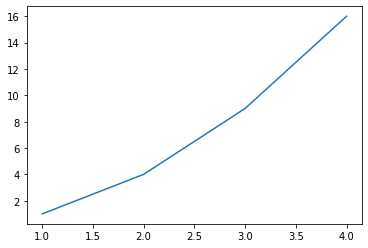

```python
from matplotlib.pyplot import plot
plot([1,2,3,4],[1,4,9,16]);
```

**Jorge I. Zuluaga**

**NOTAS AL PIE:**

Indice | Siguiente: Agradecimientos